# Kamera bevezető

Mai világunkban a digitális kamerák szinte mindenhol megtalálhatók és lényegében a mobiltelefonoknak köszönhetően mindenki használja is őket. Ezek az eszközök és a hozzá tartozó alkalmazások nagyon egyszerűvé tették a fényképezést és a videó készítést, aminek következtében szinte alig tudunk bármit is, hogy mi is történik akkor amikor a kamerával kommunikálunk.

## Mi a kamera

A digitális kamerák általában álló vagy mozgó képek rögzítésére szolgálnak és detektorként egy elektronikus képrögzítő szenzort használnak. Ehhez társul még egy optikai rendszer ami képes a megfigyelt képet a kamera szenzorára leképezni (fókuszálni). A régebbi, analóg kamerkákban a kép rögzítése filmtekercsre történt vegyi folyamatokat kihasználva.

## Kamera tulajdonságai

A teljesség igénye nélkül felsorolunk néhány fontosabb fogalmat és paramétert a kamerákkal kapcsolatban amik segíthetnek megérteni a kamerával való munkát és kiválasztani az adott feladathoz az ideális kameratípust.

**Megapixel szám**

Az elektronikus szenzor pixelekre van osztva, ezek a legkisebb egységei a képnek. Minél több pixelje van a szenzornak annál nagyobb a felbontóképessége (rezolúciója), azaz jobb minőségű kép készítésére képes. 5 Megapixel felbontású kép digitálisan már egész elfogadható, de ha nyomtatásban is jó minőséget szeretnénk, akkor érdemesebb 10 Megapixel fölötti szenzort keresni.

**Kép minőség**

Minél nagyobb a kamera szenzora annál jobb a kép minősége főként alacsony intenzitású fényviszonyok mellett.

**RAW mód**

A legtöbb digitális kamera képes .JPEG formátum készítésére, ami egy tömörítési módja a fényképek készítésének és információvesztéssel jár. A RAW mód tartalmazza az összes információt a készített képről és minden pixelt is, viszont elég nagy helyet foglal el.

**FPS**

Ez a frame per secundum rövidítése, hogy hány képet képes másodpercenként kiolvasni. 60 fps-nél a videók már elég élesek és simulékonyan követik a képek egymást. Ennek van egy limitje, ami kamera/szenzor jellemző. Átlagos kamerák 30 fps-re képesek.

**Expozíciós idő állítása**

Vannak olyan kamerák, ahol szabályozható, hogy mennyi ideig rögzítse a szenzor a fényt. Sötétben, érdemes hosszú ideig rögzíteni, hogy a kép részletei kirajzolódjanak a zajból, míg ha gyors folyamatokat akarunk megörökíteni, akkor az expozíciós időt le kell csökkenteni.

## Kamera a Raspberry Pi-on

A Raspberry Pi-re lényegében bármelyik USB-s, CSI-os esetleg ethernetes kamerát ráköthetjük és vezérelhetjük, ha rendelkezünk megfelelő driverekkel. Elviekben a CSI (Camera Serial Interface) tud leggyorsabban kommunikálni a processzorral (ezt használják a mobiltelefon kameráknál is).

A Raspberry Pi Foundation kiadott több saját maga tervezett kamerát is specifikusan a Raspberry Pi számítógéphez. Szinte minden paraméterüket lehet állítani és van hozzájuk megbízható driver. Annak ellenére, hogy a projektjeinket igyekszünk úgy megírni, hogy bármilyen kamerát használhassunk, bemutatjuk, hogyan lehet a Raspberry Pi Camera Module-t a számítógéphez csatlakoztatni, avval a kommunikációt engedélyeztetni és installálni a szükséges szoftvereket.

### Kamera installálás

A kamera hajlíthatós kábera a Raspberry Pi CAMERA-val jelölt csatlakozójába kell belehelyezni, ami az Ethernet és a HDMI portok között található. A kábel ezüstös kontaktjainak a HDMI port felé kell néznie. Ez a [videó](https://www.youtube.com/watch?v=GImeVqHQzsE) is illusztrálja, hogyan kell a kábelt csatlakoztatni. A kamera típusától függően a lencsén lehet egy fényáteresztő kékes színű plasztik fedőréteg, amit gyengéden el kell távolítani használat előtt.

A Raspberry Pi-on engedélyeznünk kell a kamera használatát. Nyissuk meg egy terminált és indítsuk el belőle a *raspi-config* programot, `sudo raspi-config`. Válaszd ki az *Interfacing Options* menüpontot, majd a *Camera* menüpontot és nyomd meg az *Enter*-t. Következőnek válaszd a *Yes*-t majd az *Ok*-t. Végül mennyj a *Finish* gombra amivel újraindítot a Raspberry Pi-t és lényegében innentől használható a kamera.

### Kamera szoftverek installálás

A Raspbian operációs rendszer rendelkezik 4 Linuxos terminálban használható szoftverrel, *raspistill*, *raspivid*, *Time-lapse* és *raspiyuv* ami képes kommunikálni a kamerával. Mivel mi főleg pythonnal foglalkozunk így az avval kapcsolatos csomagra térünk ki.

Elviekben minden Raspbian operációs rendszer rendelkezik a python *Picamera* csomagjával, ami képes a kamerával kommunikálni. A `python -c "import picamera"` parancs lefuttatásával le tudod ellenőrizni, hogy rajta van-e a gépeden. Ha nincs, akkor a következő parancsokat futtasd le a terminálban: `sudo apt-get update`, `sudo apt-get install python-picamera python3-picamera`. Ezután a használati utasítást tanulmányozva már lehet is használni. Kiemelném, hogy a **MagPi** magazinban két könyv is foglalkozik a kamerákkal, [itt](https://magpi.raspberrypi.org/books/essentials_camera_v1) meg [itt](https://magpi.raspberrypi.org/books/camera-guide).

Mi nem részletezzük a picamera modult, mert az csak a Raspberry Pi kamerájával működik. Egy általánosabb csomagot vesézünk ki, ami szinte minden kamerával működik, az OpenCV csomagot.

# Képfeldolgozás OpenCV-vel

Mi történik az emberi agyban amikor egy képet nézünk? Mi különböző mintákat keresünk az agyunkkal, mint pl. különböző alakzatok, színek, amik alapján döntést tudunk hozni a kép tartalmáról. Viszont, egy számítógép, hogy értelmezi a képeket?

Egy digitális kép kis kép elemekből épül fel, amiket pixeleknek nevezünk. Minden egyes pixelt egy véges és jól definiált számérték képvisel, ami az ő intenzitásának vagy szürkeség mértékének felel meg. Ezek a pixelek mátrixokban helyezkednek el (sorokban és oszlopokban) és meghatározott méretük van ami a kamera jellegzetessége. A számítógép ilyen számokból álló mátrixként látja a képeket és ezen mátrixok elemzésével próbál a számok között valami mintát, szabályosságot felfedezni.

A mátrixok számai különböző értékeket vehetnek fel attól függően, hogy épp melyik szabványt használták az elkészítéskor. A legtöbbször a sötétebb pixeleket kisebb számok, míg a világosabb színeket nagyobb számok képviselik. Pl. két gyakori módszer a 0-tól 1-ig terjedő intevallum vagy a 0-tól 255-ig terjedő intervallum alkalmazása.

A színes képek esetében általában 3 csatornán (mátrixon) keresztül jön az információ. Talán a legelterjettebb konvenció az RGB (red, green, blue - piros, zöld, kék) csatornás konvenció. Ebben az esetben a képet 3 db két dimenzós mátrix képviseli, ahol a mátrixok a piros, zöld és a kék színeket képviselik. Ezeket keverve, az összhatás más színek megjelenését is előidézi.

## Mi az OpenCV

Az OpenCV (Open Source Computer Vision Library) egy nyitott forrású szoftver könyvtár számítógépes látáshoz és gépi tanuláshoz. Azért hozták létre, hogy az alkalmazások egy közös infrastruktúrára támaszkodjanak ha gépi látásról vagy a gépi tanulás felgyorsításáról van szó. BSD-licensz alatt áll így bárki egyszerűen használhatja és akár változtathatja a forráskódot.

Optimalizált C / C++ nyelven iródott és egy interféjszen keresztül támogatja a Java és Python nyelveket. Használatával néhány összetett feladat, mint pl. arcfelismerés, tárgy azonosítás, emberi cselekvés felismerése videókban, mozgó tárgyak követése egyszerűbbé válik.

## OpenCV installálása

Sokféleképp installálható az OpenCV csomag. Ha az Anaconda környezet installálva van a számítógépen akkor a `conda install -c conda-forge opencv` paranccsal telepíthető az OpenCV csomag.

`pip`-el való installáláshoz a leírás [itt](https://pypi.org/project/opencv-python/) található, és elviekben a következő parancsnak működnie kell: `pip install opencv-python`.

## Képek olvasása és írása (read/save)

A képek manipulálásához először meg kell tanulnunk, hogyan olvassuk be a képeket a memóriába az OpenCV-t használva. Első lépésként importáljuk a szükséges csomagokat. Az OpenCV-t az `import cv2` paranccsal olvashatjuk be. Magának a OpenCV-nek van külön parancsa a képek ábrázolására, `cv2.imshow`, de ez a dokumentum Jupyter Notebookban írodik, ami nem engedélyezi annak használatát, így a `matplotlib.pyplot` csomagra fogunk hagyatkozni ebben a kérdésben. Ezenfelül beimportáljuk az `os` csomagot is, hogy a fájlok útvonalait megtervezhessük.

Lementettünk egy `hamster.png` nevű képet a `bevezeto` nevű mappába. Hogy a dokumentumunkhoz képest megszerkeszthessük a kép fájl relatív útvonalát felhasználjuk az `os.path.join` függvényt, ami operációs rendszertől függetlenül megszerkeszti a helyes útvonalat.

```python
import cv2
import os
import matplotlib.pyplot as plt

path = 'bevezeto'
fname = 'hamster.png'
fullname = os.path.join(path, fname)
print(fullname)
```

```
bevezeto\hamster.png
```

A kép beolvasása innentől kezdve egyszerű, a `cv2.imread(fullname)` paranccsal.

```python
img = cv2.imread(fullname)
```

Ábrázoljuk a képet a `matplotlib.pyplot.imshow` függvény segítségével.

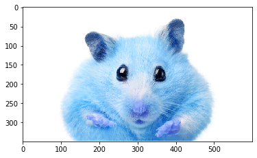

```python
plt.imshow(img)
```

Érdekes mód egy kék egeret kaptunk (nem szándékosan kék, az eredeti képen egy aranyszínű szíriai hörcsög található). Ennek a színnek az az oka, hogy az OpenCV és a matplotlib másképp értelmezik a szín csatornákat. Az OpenCV standardja a BGR (blue, green, red - kék, zöld, piros), míg a matplotlib standardja az RGB (red, green, blue - piros, zöld, kék). Ha az `cv2.imshow` függvényt használtuk volna (mondjuk egy Ipython terminálban), akkor szabályosan jelent volna meg.

Ahhoz, hogy a matplotlibbel is kompatibilissé tegyük a színkódokat, használjuk a `cv2.cvtColor` függvényét ami képes megváltoztatni a kép színpalettáját. Első paraméternek meg kell adni a kép nevét, másodiknak pedig, hogy milyen színskálából milyenbe szeretnénk átváltani (kb. 150 ilyen beépített színskála van az OpenCV-ben). Mi a `cv2.COLOR_BGR2RGB` leképezést használjuk, hogy a BGR-ből, RGB-t kapjunk.

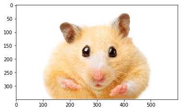

```python
img = cv2.cvtColor(img, cv2.COLOR_BGR2RGB)
plt.imshow(img)
```

Mostmár a matplotlibbel is szabályosan jelent meg a hörcsög képe. Ha elégedettek vagyunk az így kapott képpel, mentsük le a tárhelyünkre a `bevezeto/hamster_saved.jpeg` név alá a `cv2.imwrite` paranccsal. A parancs visszaadott értéke megmondja sikeres volt-e a mentés vagy sem.

```python
status = cv2.imwrite('bevezeto/hamster_saved.jpeg', img)
print(f'Sikerult a mentes? : {status}')
```

```
Sikerult a mentes? : True
```

## A kép pixeljeinek kinyerése és módosítása

Ahogy már említettük a képek kis pixelekből állnak össze, amik intenzitását egy számmal jelölünk. Ezeket az értékeket kiolvashatjuk és módosíthatjuk is a képben. A kiolvasásá többféleképp is történhet.

```python
print(img[100,100])    # feher
print(img[300,250])    # horcsog orra
blue = img[300,250,0]  # b=0, g=1, r=2
print(blue)
```

```
[255 255 255]
[242 185 108]
242
```

Most nézzük, hogy lehet módosítani a pixelek értékét. Először másoljuk le a képünket egy új változóba, `img.copy()`, hogy az eredetit később is tudjuk használni. Az indexeléssel kiválaszthatunk egy pixelt, vagy pixel tartományt és az egyenlőség jel után megadjuk, hogy mekkora legyen az intenzitása. Ha az indexekben a `:` jelet használjuk, akkor az adott tengely összes elemét válasszuk ki.

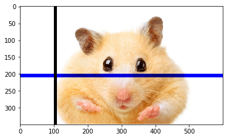

```python
stripe = img.copy()          # kep masolasa
# a vizszintes tengelyen a 100 es 110 indexu oszlopok intenzitasat 0-ra
# valtoztatjuk mind a 3 szinben
stripe[:,100:110,:] = 0
# a fuggoleges tengelyen a 200 es 210 indexu sorok intenzitasat
# a piros (0) es zold (1) szineknel 0-ra valtoztatjuk
stripe[200:210,:,0:2] = 0
plt.imshow(stripe)
```

A második módja a pixelek kiválasztásának az `item` metódus, amiben megadjuk, mely indexű pixelre vagyunk kíváncsiak. Bemenő paraméterként három számot adhatunk meg, mint az előző módszernél, a sor, oszlop és a szín indexét. Ennek a módszernek az algoritmusa kicsit jobban optimalizált, így gyorsabban lefut (persze kis adatmennyiségnél ez nem számít).

```python
stripe.item(100,3,2)
```

```
255
```

Az `itemset` metódussal meg is tudjuk változtatni a pixel intenzitását. Első paraméterként egy *tuple*-t adunk meg, ami a megváltoztatandó pixel indexét képviseli, második paraméterként pedig az új intenzitás értéket.

```python
# a 100-ik oszlop, 3-ik soraban a kek komponens intenzitasat 100-ra allitjuk
stripe.itemset((100,3,2), 100)
stripe.item(100,3,2)
```

```
100
```

## A kép tulajdonságainak olvasása

Sokszor fontos ismernünk a képben szereplő pixelek számát, a sorok, oszlopok és csatornák számát. A `shape` metódus pont a sorok, oszlopok és csatornák számát adja vissza.

```python
img.shape
```

```
(350, 600, 3)
```

Ha a képünk szürke és nem színes lenne, akkor a `shape` metódus csak két elemű tuple-t adna vissza a sorok és oszlopok számával. A `size` metódus a képben található összes pixel számot adja meg, azaz 350 x 600 x 3 pixel a fenti esetben.

```python
img.size
```

```
630000
```

A pixeleket alkotó számok típusát a `dtype` metódussal tudhatjuk meg. Sokszor helytelen típust feltételezve kapunk hibaüzenetet a pythontól, így a típus lekérdezése rendkívül fontos.

```python
img.dtype
```

```
dtype('uint8')
```

## A kép kiválasztott tartománya (ROI - region of interest)

Sokszor előfordul, hogy nem vagyunk érdekeltek a teljes képben, hanem annak csak egy szeletében, ROI. Az indexelős módszerrel kiválaszthatjuk magunknak a kép ROI részét, pl. a hörcsögöt beskatulyázó részt.

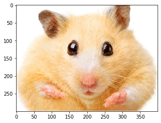

```python
plt.imshow(img[50:,100:500])
```

## Színek szétválasztása és egyesítése

Az is megeshet, hogy a színekkel egyenként akarunk dolgozni, így szét kell a képet bontani színeire. Ezt a `split` metódussal tudjuk elérni.

Természetesen, ha szét tudjuk választani a színeket, akkor szükség van arra is, hogy összerakjuk. Ezt a `merge` metódussal érjük el, csak vigyázzunk, hogy a bemenő paraméterként megadott szín komponensek sorrendje megfelelő legyen.

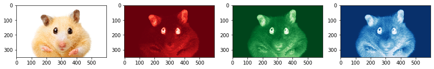

```python
r,g,b = cv2.split(img)
img_merge = cv2.merge((r,g,b))

# egy figura es 4 axes letrehozasa
fig, ax = plt.subplots(1,4, figsize=(15,30))
ax[0].imshow(img_merge)         # eredeti kep
ax[1].imshow(r, cmap='Reds')    # piros komponens
ax[2].imshow(g, cmap='Greens')  # zold komponens
ax[3].imshow(b, cmap='Blues')   # kek komponens
```

## Képek újraméretezése

Amikor képekkel dolgozunk, gyakran előfordulhat, hogy a kép méretét meg kell változtatnunk, pl. gépi tanulás alkalmazásakor az algoritmus nagyban felgyorsítható, ha kisebb képekkel dolgozunk. A kép méretének módosításához a `resize()` metódust használjuk.

`cv2.resize(s, size,fx,fy,interpolation)`

- s - bemenő kép (kötelező megadni).
- size - a kívánt méret. Ez egy tuple ami a kép szélességét és magasságát képviseli (kötelező megadni).
- fx - skálázási faktor a vízszintes tengely irányába (opcionális).
- fy - skálázási faktor a függőleges tengely irányába (opcionális).
- interpolation (opcionális) - This flag uses following methods:
  - INTER_NEAREST – a legközelebbi szomszéd interpoláció.
  - INTER_LINEAR – a bilineáris interpoláció (alapértelmezett)
  - INTER_AREA – újra mintavételezés felhasználva a pixel területi összefüggéseit.
  - INTER_CUBIC – a bicubic interpoláció egy 4×4 pixel szomszédságban.
  - INTER_LANCZOS4 – a Lanczos interpoláció egy 8×8 pixel szomszédságban.

A lenti példában megnöveljük a kép méretét 780 pixel szélesre és 540 pixel magasra.

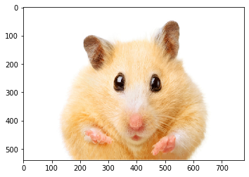

```python
img_resized=cv2.resize(img, (780, 540))
plt.imshow(img_resized)
```

## Képek forgatása

A képek elforgatásához 3 dolgot kell ismernünk: a) hány fokkal szeretnénk elforgatni a képet, b) a forgatás középpontjának koordinátáit, c) szeretnénk-e nagyítani vagy kicsinyíteni a képen (skálázás).

Ezt az OpenCV két lépésben teszi számunkra lehetővé:

1) A fent megadott 3 paraméter alapján kiszámolja a forgatáshoz szükséges forgató mátrixot a `cv2.getRotationMatrix2D(center, degree, scale)` függvénnyel, ahol a `center` a forgatás középpontjának koordinátája, a `degree` a forgatás szöge és a `scale` a skálázás mértéke.

2) A forgató mátrixszal elforgatjuk a képet és a forgatás miatt keletkezett üres tereket feltöltjük feketével a `cv2.warpAffine(img, M, (w,h))` függvénnyel, ahol az `img` a kép amit forgatni akarunk, `M` a forgatási mátrix, `(w,h)` pedig egy tuple ami megadja a kép szélességét `w` és magasságát `h` a forgatás után.

```
[[  0.70710678   0.70710678 -35.87572106]
 [ -0.70710678   0.70710678 263.38834765]]
```

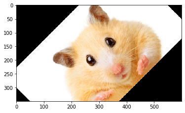

```python
(h, w) = img.shape[:2]  # meghatarozzuk a kep meretet
# kiszamoljuk a kep kozepenek koordinatait
center = (w / 2, h / 2)

scale = 1.0   # skalazasi faktor

# 45 fokos forgato matrix a kep kozeppontja korul
M = cv2.getRotationMatrix2D(center, 45, scale)
print(M)
# 45 fokos forgatas
rotated45 = cv2.warpAffine(img, M, (w, h))
plt.imshow(rotated45)
```

## Thresholding

Thresholding az egy módszer ami képes élesen elválasztani, szegmentálni a különböző intenzitású területeket a képen. Sok technika létezik a thresholdingon belül is szegmentálásra, pl. egyszerű thresholding és adaptív thresholding. Mi az elsővel foglalkozunk itt.

Az egyszerű thresholdinghoz elsősorban szürke skálájú képre van szükség, ezért első lépésként a hörcsög képét átalakítjuk szürke skálára, `cv2.cvtColor(img, cv2.COLOR_RGB2GRAY)`.

Az egyszerű thresholding alapötlete egyszerű: ha a pixel intenzitása nagyobb mint egy adott érték, akkor azokhoz a pixelekhez egy előre meghatározott értéket rendelünk, pl. fehér, minden máshoz egy másik értéket rendelünk, pl. fekete. Ezt a `cv2.threshold(img, threshold, maxVal, thresholdingTechnique)` függvény végzi el, ahol az `img` a bemenő kép, a `threshold` az értékhatár ami alatt és felett megváltozik a pixelek intenzitása, a `maxVal` a maximum intenzitás érték amire változtatjuk a pixeleket és a `thresholdingTechnique` a módszer amivel elvégezzük a szegmentációt. Ezeket a módszereket a lenti példánkban egyenként bemutatjuk, a részletes leírásukért érdemes felkeresni a [dokumentációjukat](https://www.geeksforgeeks.org/python-thresholding-techniques-using-opencv-set-1-simple-thresholding/).

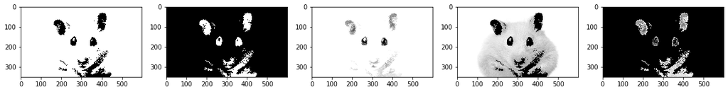

```python
gray = cv2.cvtColor(img, cv2.COLOR_RGB2GRAY) # szurke szinskala
threshold=160             # threshold beallitasa
ret, thresh1 = cv2.threshold(gray, threshold, 255, cv2.THRESH_BINARY)
ret, thresh2 = cv2.threshold(gray, threshold, 255, cv2.THRESH_BINARY_INV)
ret, thresh3 = cv2.threshold(gray, threshold, 255, cv2.THRESH_TRUNC)
ret, thresh4 = cv2.threshold(gray, threshold, 255, cv2.THRESH_TOZERO)
ret, thresh5 = cv2.threshold(gray, threshold, 255, cv2.THRESH_TOZERO_INV)

# figura es axes inicializalasa
fig, ax = plt.subplots(1,5, figsize=(20,30))
ax[0].imshow(thresh1, cmap='gray')
ax[1].imshow(thresh2, cmap='gray')
ax[2].imshow(thresh3, cmap='gray')
ax[3].imshow(thresh4, cmap='gray')
ax[4].imshow(thresh5, cmap='gray')
```

## Blur effektus

A blur (blör) effektus az egy olyan kép feldolgozási technika ami segít eltüntetni a zajt a képről. Eltünteti a kis intenzitású széleket, a nagyfrekvenciás változásokat és segít eltüntetni a részleteket is. Például ezt használjuk ha egy bizalmas információt szeretnénk eltüntetni a képről vagy a kép egy részének részleteit felismerhetetlenné szeretnénk tenni. Sok fajta blur módszer van, pl. átlagolás, medián számítás, Gauss símítás, bilaterális szürő stb. Mi ebből az átlagoló símítást fogjuk áttekinteni.

Az átlagolós símításnál meg kell adni, egy kernel területet (doboz szűrő), amivel végigpásztázva a képet, az épp alá eső terület intenzitás értékeit kiátlagolja és ez az átlag lesz az értéke a lefedett terület középponti pixeljének. Ezt a `cv2.blur(src, ksize,anchor, borderType)` függvénnyel tudjuk elvégezni, ahol a `src` a bemenő kép, a `ksize` egy tuple ami a kernel szélességét és magasságát adja meg pixelekben, az `anchor` (opcionális) ami befolyásolja mi legyen a kernel közepe és a `borderType` (opcionális) a szélek típusát képviseli.

Az alábbi ábrán egy 10 x 10 pixeles és egy 30 x 30 pixeles kernelt használunk a pixelek átlagolásához. Látható, hogy az utóbbi esetben, ahol a kernel mérete nagyobb, jobban szétmosódnak a részletek.

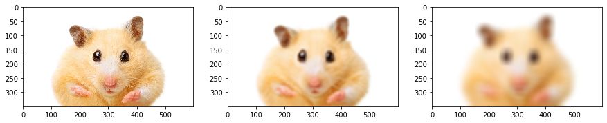

```python
# 10 x 10-es kernel merettel atlagolas
blur1 = cv2.blur(img, (10,10))
# 30 x 30-as kernel merettel atlagolas
blur2 = cv2.blur(img, (30,30))

# figura es axes inicializalasa
fig, ax = plt.subplots(1,3, figsize=(15,30))
ax[0].imshow(img)
ax[1].imshow(blur1)
ax[2].imshow(blur2)
```

## Kép effektusok

Az OpenCV tartalmaz olyan függvényeket, amivel a képeinken akár artisztikusabb effektusokat is létrehozhatunk. Ezeket az effektusokat mint érdekesség említjük meg, ha valakit komolyabban érdekel nézzen utána a referenciában javasolt irodalomban vagy a függvények dokumentációjában.

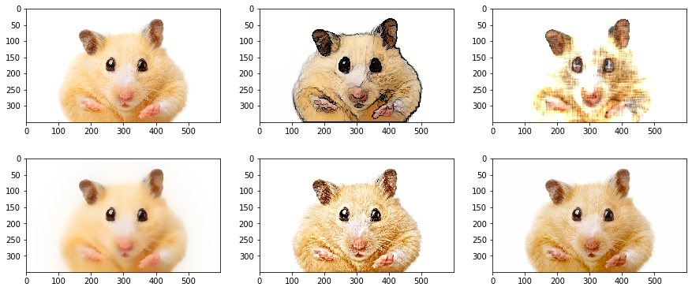

```python
# stilizacio
cartoon_image = cv2.stylization(img, sigma_s=150, sigma_r=0.25)
# szketch jellegu kepatalakitas szurkeskalan es szinesben
cartoon_image1, cartoon_image2  = cv2.pencilSketch(img, sigma_s=60, sigma_r=0.5, shade_factor=0.02)
# eleket meghagyo szures
dst = cv2.edgePreservingFilter(img, flags=1, sigma_s=60, sigma_r=0.4)
# reszleteket kiemelo szures
dst1 = cv2.detailEnhance(img, sigma_s=10, sigma_r=0.15)
grayscale, color_boost = cv2.decolor(img)

# figura es axes inicializalasa
fig, ax = plt.subplots(2,3, figsize=(15,7))
# a kepsorok kozti fuggoleges tavolsag beallitasa
fig.subplots_adjust(hspace=0)
ax[0,0].imshow(img)
ax[0,1].imshow(cartoon_image)
ax[0,2].imshow(cartoon_image2)
ax[1,0].imshow(dst)
ax[1,1].imshow(dst1)
ax[1,2].imshow(color_boost)
```

## Folytonos képfelvétel

Nem csak fájlból tervezünk képeket kiolvasni, hanem a webcameránkkal is szeretnénk képeket készíteni (vagy videókat), és erre is ad lehetőséget az OpeCV. Lényegében mind a kép, mind az élőkép (videó) készítése ugyanavval a módszerrel történik, hiszen a videó nem más, mint újabb és újabb fényképek készítése és gyors megjelenítése egymás után.

Első lépésként beimportáljuk a `time` csomagot, hogy késleltetéseket be tudjunk vezetni. A kameránk inicializálásához a `cap = cv2.VideoCapture(0)` parancsot kell használni. A `0` a számítógépünk fő kamerájára utal. Ha több is van csatlakoztatva, akkor az `1`, `2`, stb. számokkal lehet rájuk hivatkozni. A `cap.isOpened()` függvénnyel leellenőrizhetjük, hogy sikeres volt-e az inicializáció, ha épp akarjuk. Ha ennek az eredménye `False`, akkor próbáljuk megnyitni a `cap.open()` paranccsal.

Ha egy képet tervezünk készíteni, akkor egyszerűen csak írjuk be a `ret, frame = cap.read()` parancsot, ahol a `ret` értéke igaz vagy hamis, annak függvényében, hogy sikerült-e fényképezni vagy sem, a `frame` változó pedig a képet magát tartalmazza. A kép megjelenítéséhez használhatjuk az OpenCV `cv2.imshow('frame', frame)` parancsát, ahol a string az ablak nevét, a második paraméter pedig a megjelenítendő képet jelenti. De a `matplotlib.pyplot` csomag `imshow` függvényét is hasznákhatjuk.

Ha nem képet, hanem folytonos videót szeretnénk látni, akkor a fenti parancsot egy végtelen `while` ciklusba kell helyezni (mint ahogy a lenti példában látjuk) és minden ciklus közé egy minimális késleltetést érdemes bevinni pl. `time.sleep(0.5)`.

Természetesen a végtelen ciklust mindig meg lehet állítani a CTRL+C billentyű kombinációval, de egy elegánsabb módja, ha minden ciklusban megvizsgáljuk, hogy pl. megnyomták-e a `q` billentyűt, `if cv2.waitKey(1) == ord('q'):` és ha igen, akkor kilépünk a ciklusból, `break`.

Ezután fontos, hogy megszakítsuk a kamerával a kommunikációs csatornát (ha nem akarjuk tovább használni), `cap.release()`, illetve bezárjunk minden ablakot amit megnyitottunk, `cv2.destroyAllWindows()`.

```python
import time

cap = cv2.VideoCapture(0)    # kamera inicializalasa

while True:                  # vegtelen ciklus
    ret, frame = cap.read()  # kep kiolvasasa
    cv2.imshow('kep', frame) # kep megjelenitese
    time.sleep(0.5)          # 0.5 masodperc szunet

    # megvizsgaljuk megnyomtak-e a q betu billentyujet
    if cv2.waitKey(1) == ord('q'):
        break   # ha igen, akkor kilepunk a while ciklusbol

# Ha nem hasznaljuk tovabb a kamerat, megszakitjuk az osszekottetest
cap.release()
# Bezarunk minden ablakot, amit a program megnyitott
cv2.destroyAllWindows()
```

Az OpenCV is ad lehetőséget a kamera egyes paramétereinek beállításához. Erről egy [lista](https://docs.opencv.org/2.4/modules/highgui/doc/reading_and_writing_images_and_video.html#videocapture-get) is van a leírásban. A `cap.get(propId)` parancs adja vissza a kamera aktuális paramétereit, ahol a `propId` 0 - 18 -ig menő számok, és mindegyik szám a kamera egy tulajdonságának felel meg. Ezekre a számokra változókként is lehet hivatkozni, ami kicsit beszédesebb és mindenki megérti, nem kell a számozást fejben tartani. Pl. a 3-ra hivatkozhatunk a `cv2.CAP_PROP_FRAME_WIDTH` név megadásával, ami a kép szélességét jelenti pixelekben. Tehát, ha le akarjuk ellenőrízni a készítendő kép szélességét és magasságát, akkor a következő parancsokat használhatjuk: `cap.get(cv.CAP_PROP_FRAME_WIDTH)` és `cap.get(cv.CAP_PROP_FRAME_HEIGHT)`. Ha pl. az alapértelmezett érték 640x480 és szerenténk azt módosítani 320x240-re akkor a következő parancsokat írjuk be: `cap.set(cv.CAP_PROP_FRAME_WIDTH, 320)` és `cap.set(cv.CAP_PROP_FRAME_HEIGHT, 240)`.

# Referencia

1) https://opencv-python-tutroals.readthedocs.io/en/latest/py_tutorials/py_setup/py_table_of_contents_setup/py_table_of_contents_setup.html

2) https://www.mygreatlearning.com/blog/opencv-tutorial-in-python/#sh1

3) https://www.edureka.co/blog/python-opencv-tutorial/

4) https://www.c-sharpcorner.com/article/cartoon-effect-and-pencil-sketch-using-open-cv-in-python/

5) https://picamera.readthedocs.io/en/release-1.13/fov.html

6) https://www.raspberrypi.org/documentation/hardware/camera/README.md

7) https://www.raspberrypi.org/documentation/linux/software/libcamera/csi-2-usage.md

8) Pi kamera bekötése - https://www.youtube.com/watch?v=GImeVqHQzsE

9) Pi kamera magazin - https://magpi.raspberrypi.org/books/camera-guide

10) Pi kamera magazin - https://magpi.raspberrypi.org/books/essentials_camera_v1

11) OpenCV kamera parameterek - https://docs.opencv.org/2.4/modules/highgui/doc/reading_and_writing_images_and_video.html#videocapture-get